# verkefni1

Viktor Hamrar & Þórgnýr Thoroddsen

1/17/2017

# Hluti 1 - innlestur gagna og smá gagnamöndl (30%)

### a)

Lesið gagnaskrána inn með read.table() skipuninni og geymið í hlut sem ber upphafsstafi þeirra sem verkefnið vinna (ef Gréta Halldórsdóttir og Sigurður Jónsson eru að vinna saman skulu þau nefna hlutinn gs en ef Atli Pétursson er að vinna einn skal hann nefna hlutinn sinn ap).

```r
thv <- read.table("./data/husnaedi.txt", header = TRUE, sep = ";")
```

### b)

Veljið ykkur þrjú hverfi á Reykjavíkursvæðinu til að skoða. Gætið þess að velja hverfi með mörgum eignum. Það sem eftir er verkefnisins skulið þið aðeins vinna með eignir í þessum þremur hverfum. Það má velja hverfin út með nokkrum aðferðum en ágætt er að nota filter() aðferðina úr dplyr pakkanum. Þið þurfið að byrja á því að sækja pakkann og svo þarf að muna eftir að setja library(dplyr) ofarlega í skjalið ykkar (í R-klump) og keyra þá línu í hvert skiptið sem þið opnið RStudio á ný og ætlið að vinna í verkefninu ykkar. Velja mætti hverfi 1, 2, og 3 með eftirfarandi kóða (þetta eru ekki raunveruleg hverfi í gagnasafninu ykkar):

```r
hverfi <- c(20, 100, 200)
thv <- filter(thv, thv$matssvaedi%in%hverfi)
```

### c)

Kannið gerð breyta gagnasafnsins með að nota str() aðferðina. Ef einhverjar breytur eru ranglega skilagreindar sem talnabreytur skulið þið breyta þeim í flokkabreytur og mögulega endurnefna flokkana. Sýnið aftur úttakið úr str() aðferðinni eftir að þið hafið breytt þeim breytum sem þið ætlið að breyta.

```r
str(thv)
```

```
## 'data.frame':    3393 obs. of  4 variables:
##  $ nuvirdi   : int  18636 14472 14850 24503 36386 17434 26945 23800 15100 33891 ...
##  $ teg_eign  : Factor w/ 2 levels "Einbýlishús",..: 2 2 2 2 2 2 2 2 2 1 ...
##  $ matssvaedi: int  200 20 200 100 100 200 100 100 20 100 ...
##  $ ibm2      : num  117 45.7 78.1 100.8 119.4 ...
```

```r
##Eins og sjá má eru matssvæðin ranglega skilgreind sem tölugildi. Svo við breytum þeim í faktor og köllum matssvæðin nýjum nöfnum.
thv$matssvaedi <- as.factor(thv$matssvaedi)
levels(thv$matssvaedi) <- c("Midbaer", "LaugarnesVogar", "Arbaer")
str(thv)
```

```
## 'data.frame':    3393 obs. of  4 variables:
##  $ nuvirdi   : int  18636 14472 14850 24503 36386 17434 26945 23800 15100 33891 ...
##  $ teg_eign  : Factor w/ 2 levels "Einbýlishús",..: 2 2 2 2 2 2 2 2 2 1 ...
##  $ matssvaedi: Factor w/ 3 levels "Midbaer","LaugarnesVogar",..: 3 1 3 2 2 3 2 2 1 2 ...
##  $ ibm2      : num  117 45.7 78.1 100.8 119.4 ...
```

# Hluti 2 - myndræn framsetning (30%)

### a)

Teiknið mynd sem sýnir fjölda eigna eftir hverfum og tegundum eigna (á sömu myndinni).

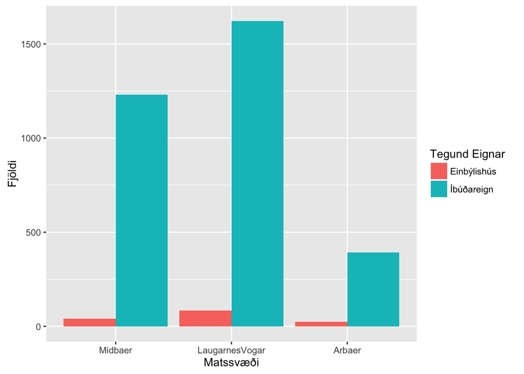

```r
plott1 <-
  ggplot(aes(matssvaedi), data = thv) +
  geom_bar(position = "dodge", aes(fill = thv$teg_eign)) +

##X og Y labels
  xlab("Matssvæði") + ylab("Fjöldi") +

##Legend
  scale_fill_discrete(name = "Tegund Eignar")

plott1
```

### b)

Teiknið mynd sem er lýsandi fyrir stærð einbýlishúsa eftir hverfum. Hér má nota filter() aðferðina til að búa til nýja gagnatöflu sem inniheldur aðeins einbýlishús. Það má gera með:

> einbyli<-filter(ahj, teg_eign == “Einbýlishús”)

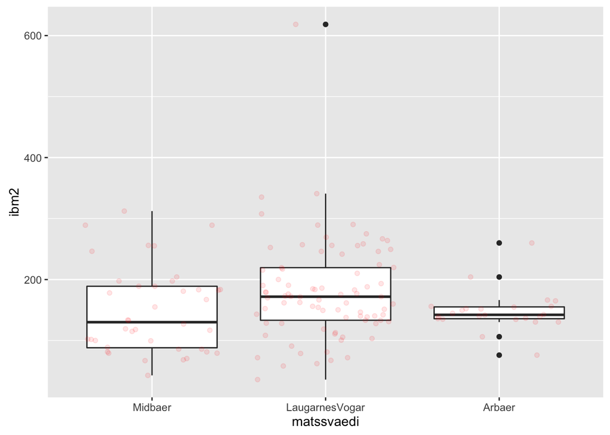

```r
einbylishus <- dplyr::filter(thv, teg_eign == "Einbýlishús")
plott2 <-
  ggplot(aes(matssvaedi, ibm2), data = einbylishus) + geom_boxplot() + geom_jitter(alpha = 0.1, color = "red")

plott2
```

### c)

Búið til nýtt gagnasafn sem inniheldur aðeins íbúðareignir. Teiknið mynd sem lýsir sambandi stærðar og verðs íbúðareigna.

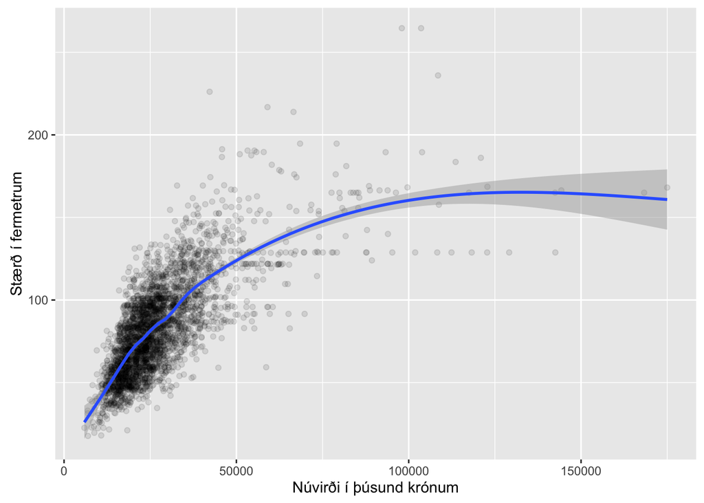

```r
ibudir <- dplyr::filter(thv, teg_eign == "Íbúðareign")
plott3 <-
  ggplot(aes(nuvirdi, ibm2),
        data = ibudir) +
  ## How to plot
        geom_point(alpha = 0.1) +
        geom_smooth() +
  ## X and Y labels
        xlab("Núvirði í þúsund krónum") + ylab("Stærð í fermetrum")

plott3
```

# Hluti 3 - lýsistærðir (30%)

### a)

Búið til töflu þar sem má sjá fjölda einbýlishúsa og íbúðareigna í hverfunum þremur (það á að vera hægt að lesa hversu margar íbúðir eru í fyrsta hverfinu sem þið völduð osfrv.). Búið til aðra töflu sem sýnir hversu hátt hlutfall af heildarfjölda eigna í hverju hverfi fyrir sig eru íbúðareignir.

```r
table(thv$teg_eign, thv$matssvaedi)
```

```
##
##               Midbaer LaugarnesVogar Arbaer
##   Einbýlishús      40             84     24
##   Íbúðareign     1230           1622    393
```

```r
prop.table(table(thv$teg_eign, thv$matssvaedi), 2)
```

```
##
##                  Midbaer LaugarnesVogar     Arbaer
##   Einbýlishús 0.03149606     0.04923798 0.05755396
##   Íbúðareign  0.96850394     0.95076202 0.94244604
```

### b)

Reiknið viðeigandi lýsistærðir, fyrir miðju og breytileika, fyrir stærð einbýlishúsa eftir hverfum.

```r
einbyl.midbaer <- einbylishus %>%
  filter(matssvaedi == "Midbaer")

einbyl.LaugarnesVogar <- einbylishus %>%
  filter(matssvaedi == "LaugarnesVogar")

einbyl.Arbaer <- einbylishus %>%
  filter(matssvaedi == "Arbaer")
```

Meðalstærð einbýlishúsa í Miðbæ er 148.8575.  
Meðalstærð einbýlishúsa í Laugarnesi/Vogum er 180.3678571.  
Meðalstærð einbýlishúsa í Árbæ er 147.8958333.  
Miðstærð einbýlishúsa í Miðbæ er 130.15.  
Miðstærð einbýlishúsa í Laugarnesi/Vogum er 171.9.  
Miðstærð einbýlishúsa í Árbæ er 142.2.  
Breytileiki stærðar einbýlishúsa í Miðbæ er 4875.0917372.  
Breytileiki stærðar einbýlishúsa í Laugarnesi/Vogum er 6641.8477496.  
Breytileiki stærðar einbýlishúsa í Árbæ er 1086.2899819.

### c)

Búið til nýtt gagnasagn sem inniheldur íbúðareignir sem eru á bilinu frá og með 50m250m2 til og með 60m260m2 á stærð. Það má enn og aftur gera með filter() aðferðinni:

> litlar<-filter(ibudir, ibm2>=50 & ibm2 <=60)

Sýnið meðalverð, miðgildi verðs og staðalfrávik þessa íbúðareigna eftir hverfunum þremur. Sýnið einnig fjölda eigna í hverju hverfi.

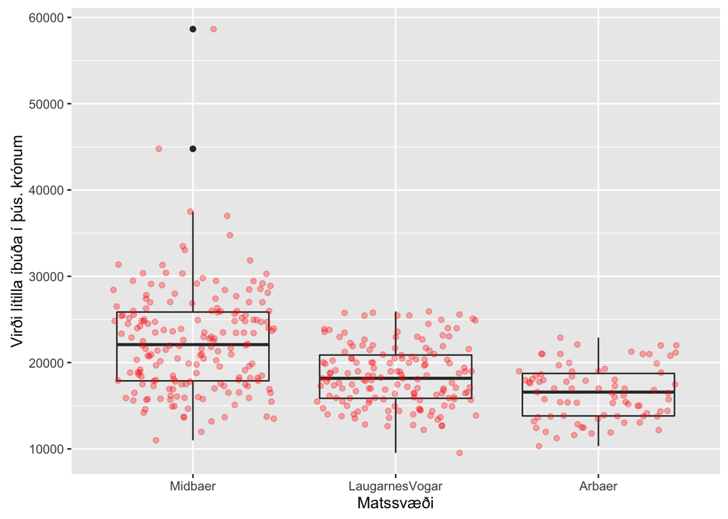

```r
litlar <- filter(ibudir, ibm2>=50 & ibm2 <=60)
ggplot(data = litlar, aes(matssvaedi, nuvirdi))+
  ## How to plot
        geom_boxplot(alpha=0.1)+
        geom_jitter(alpha = 0.3, color = "red")+
  ## X and Y labels
        xlab("Matssvæði") + ylab("Virði lítilla íbúða í þús. krónum")+
        scale_y_continuous(breaks = c(0,10000,20000,30000,40000,50000,60000))
```